# Ravelin

```python
%%bash -x
pip install xgboost
```

[output not shown]

```python
import pandas as pd
import numpy as np

import json
import flatten_json
from flatten_json import flatten
from pandas.io.json import json_normalize

import seaborn as sns
from mpl_toolkits.mplot3d import Axes3D
import matplotlib.lines as mlines
import matplotlib.pyplot as plt
from wordcloud import WordCloud, STOPWORDS

from scipy import stats
import statsmodels.api as sm

from itertools import combinations, permutations

from sklearn.feature_selection import RFE
from sklearn.preprocessing import MinMaxScaler
from sklearn.model_selection import train_test_split, learning_curve

from sklearn.linear_model import LogisticRegression
from sklearn import metrics
from sklearn.metrics import confusion_matrix, f1_score, roc_auc_score, roc_curve

from xgboost.sklearn import XGBClassifier
from xgboost import plot_importance

from keras.models import Sequential
from keras.layers import Dense, Dropout
```

```python
# resize the notebook
from IPython.core.display import display, HTML
display(HTML("<style>.container { width:100% !important; }</style>"))

# resize the num of columns to be displayed
pd.set_option('display.max_columns', None)
pd.set_option('display.max_rows', None)
pd.set_option('max_colwidth', 500)
```

```python
# for supressing warnings
import warnings
warnings.filterwarnings("ignore")
```

Tasks done in this python notebook

- Transform the json profiles into a csv or dataframe and provide exploratory analysis of the dataset.
- Summarise and explain the key trends in the data, providing visualisations and tabular representations as necessary.
- Explain what factors you think are significant and insignificant in contributing to fraud

## 1) Transform the json profiles into a csv or dataframe and provide exploratory analysis of the dataset.

For this purpose I have create a class **LoadTransform**

```python
'''
This class takes the data location and gives the data for the analysis
'''

class LoadTransform(object):

    def __init__(self, df_loc):
        self.df_loc = df_loc

        self.data_dict = [json.loads(line) for line in open(df_loc, 'r')]
        self.len_data_dict = len(self.data_dict)

        self.df = pd.DataFrame()
        self.analysis = pd.DataFrame() #dataframe for analysis
        self.temp = pd.DataFrame() # temporary dataframe which stores customer, orders, payments & transactions data one by one

        self.length = len(self.temp) # data length of the temporary data

        self.cust_identifier = None #Primary key for customer, stores either customerPhone or customerDevice

    # flattens the data to the most granular level giving lists/sublists/dictionaries/subdictionaries as columns
    def flatten_data(self):
        return pd.DataFrame([flatten(x) for x in self.data_dict])

    # normalizes the data by 1 level
    # takes in a dictionary
    # returns a pandas dataframe
    def normalize_data(self):
        self.df = json_normalize(self.data_dict)

    # cleans customer data
    # customer data needs separate method, as this data needs only one level flattening, unline other methods
    def get_cust_data(self):
        self.df['numOrders']=self.df['orders'].str.len()
        self.df['numPaymentMethods']=self.df['paymentMethods'].str.len()
        self.df['numTransactions']=self.df['transactions'].str.len()

        self.temp = self.df[['fraudulent', 'customer.customerEmail', 'customer.customerPhone', 'customer.customerDevice', 'customer.customerIPAddress',
                      'customer.customerBillingAddress', 'numOrders', 'numPaymentMethods', 'numTransactions']]
        self.analysis = self.temp

    # to get the column at which the customer data is unique
    def unique_cust_identifier(self):
        for col in self.temp.columns:
            if (self.temp[col]).nunique()==self.len_data_dict:
                self.cust_identifier = col

    # flattens data which has more than two levels
    def get_other_data(self, col_str):

        drop_cols = ['paymentMethods', 'transactions', 'orders', 'customer.customerBillingAddress', 'customer.customerEmail',
             'customer.customerIPAddress', 'numOrders', 'numPaymentMethods', 'numTransactions']

        df_null = self.df[self.df[col_str].str.len() <1]
        self.temp = json_normalize(self.df.to_dict('records'), col_str, self.df.columns.to_list(), errors='ignore')#, record_prefix='_')
        self.temp  = self.temp.append(df_null)
        self.temp = self.temp.drop(columns=drop_cols)
        return self.temp#.drop(columns=drop_cols)

    # Convert the variables to str dtype.
    # By converting to str dtype, I am converting NaNs into "nan" as string,
    # when concatenated with other columns, the concatenated result acts as primary key.
    def convert_to_str(self):
        for c in self.temp.columns:
            #if c not in self.object_dtype:
            self.temp[c] = self.temp[c].astype(str)

    # provides primary keys stores in the temp data
    def primary_key_provider(self):
        for c in combinations(self.temp.columns,2):
            cl = len(set(self.temp[c[0]]+self.temp[c[1]]))
            if self.length==cl:
                print('Primary keys for this dataset', c, cl)

    def print_dtype_info(self):
        print('PRINT DATA TYPE INFO')
        print(self.temp.info())

    # quality checks the data merged and stores in 'analysis'
    def quality_check_merge(self, col_str):
        cust_identifier_without = self.temp[self.temp[col_str].isna()][self.cust_identifier]
        cust_identifier_with = self.temp[~self.temp[col_str].isna()][self.cust_identifier]
        return (len(set(cust_identifier_without))+len(set(cust_identifier_with)))==self.len_data_dict

    # renames the columns
    def rename_columns(self):
        # to get rid of the prefic underscore
        self.temp.rename(columns=lambda x: x.split('_')[1] if len(x.split('_'))==2 else x, inplace=True)

        # to get rid of the customer prefix
        self.temp.rename(columns=lambda x: x.split('.')[1] if len(x.split('.'))==2 else x, inplace=True)

    # This merges the datasets
    # the merged data is automatically saved in self.analysis
    def get_analysis_data(self, col_str=None):
        col_lst = ['customerDevice', 'fraudulent', 'customerPhone']
        if not col_str is None:
            col_lst.append(col_str)
        if not self.analysis.empty and not self.temp.equals(self.analysis):
            self.analysis = pd.merge(self.analysis, self.temp, on=col_str)

    def print_data(self):
        print('Shape of the dataset: ', self.temp.shape)
        #print('Columns in dataset', temp.columns)
        print('Num of uniques in dataset at column levels: ', self.temp.nunique())
        #print('Num of unique customer devices in the dataset is equal to json file: ', self.temp[self.cust_identifier]==self.len_data_dict)

    def print_analysis_data(self):
        self.temp = self.analysis
        self.print_data()

    # drops the columns,
    # takes lst of columns as inputs and
    # returns data after droping the input columns strings
    def drop_col(self, col_lst):
        self.temp = self.temp.drop(columns=col_lst)

    # custom add columns
    def add_cols(self):
        self.analysis['billing_add_code'] = self.analysis['customerBillingAddress'].str.split(' ').apply(lambda x: x[-1:][0])
        self.analysis['billing_add_state'] = self.analysis['customerBillingAddress'].str.split(' ').apply(lambda x: x[-2:-1][0])
        self.analysis['shipping_add_code'] = self.analysis['orderShippingAddress'].str.split(' ').apply(lambda x: x[-1:][0])
        def state_key(x):
            try:
                if len(str(x))>2:
                    return x[-2:-1][0]
                else:
                    return x
            except IndexError:
                return x[0]
        self.analysis['shipping_add_state'] = self.analysis['orderShippingAddress'].str.split(' ').apply(lambda x: state_key(x))

        new = self.analysis['customerEmail'].str.split('@')[1]
        self.analysis['emailDomain'] = new[1]

    # Main method to transform the data  #todo: write main method
    def transform_data(self, col_str=None):
        self.convert_to_str()
        self.primary_key_provider()
        self.rename_columns()
        self.get_analysis_data()
        if col_str is not None:
            self.quality_check_merge(col_str)
        self.print_data()
        self.print_dtype_info()
        print('~~~~~~~~~~~~~~~~')

    def drop_duplicate_col(self, col1, col2):
        if not (np.where(self.analysis[col1]!=self.analysis[col2])[0]):
            self.analysis.drop(columns=[col1])

    def drop_duplicate_rows(self):
        self.analysis = self.analysis.drop_duplicates()
```

```python
df_loc='F:/ravelin/customers.json'
lt = LoadTransform(df_loc=df_loc) # creates instance of the class
print('num of data points in the json file: ', lt.len_data_dict) # gets the data points in the dictionary format

lt.normalize_data() # normalize the dictionary data to one level, thus, customer column is normalized
```

```
num of data points in the json file:  168
```

For further understanding this data, I divide the json data into four datasets as follows and merge them using the methods in LoadTransform class:

- customer
- customer_orders
- customer_payments
- customer_transactions

The IDs in these columns are convered to string using the method convert_to_str,  
and then the primary keys of each datasets are stored which are used for merging the datasets  
For customer data, I found primary key for customer is either customerPhone or customerDevice.  
The resuls of finding primary keys imply that transaction and customer data are joined on the variable orderID and customer data primary key which is stored in variable cust_identifier; and transaction and payments data joined on the variable paymentMethodId and cust_identifier  
The columns are renamed for easy access and clearer understanding  
I then get the merged_data using get_analysis_data method  
A quick quality check is done on data authenticity, to avoid losing data, using quality_check_merge method  
All this is done using *transform_data method*

```python
# for customers' data
print('~~~~~~~ cleaning customer data  ~~~~~~~`')
lt.get_cust_data()
lt.transform_data()
lt.unique_cust_identifier() #This shows that the data is unique at phone or device level

# for orders' data
print('~~~~~~~ cleaning orders data  ~~~~~~~`')
lt.get_other_data(col_str='orders')
lt.transform_data(col_str='orderId')

# for payment methods' data
print('~~~~~~~ cleaning payments data  ~~~~~~~`')
lt.get_other_data(col_str='paymentMethods')
lt.transform_data(col_str='paymentMethodId')

# for transactions' data
print('~~~~~~~ cleaning transactions data  ~~~~~~~`')
lt.get_other_data(col_str='transactions')
lt.transform_data(col_str='transactionId')
```

```
~~~~~~~ cleaning customer data  ~~~~~~~`
Shape of the dataset:  (168, 9)
Num of uniques in dataset at column levels:  fraudulent                  2
customerEmail             161
customerPhone             168
customerDevice            168
customerIPAddress         165
customerBillingAddress    166
numOrders                   9
numPaymentMethods          11
numTransactions            13
dtype: int64
PRINT DATA TYPE INFO
<class 'pandas.core.frame.DataFrame'>
RangeIndex: 168 entries, 0 to 167
Data columns (total 9 columns):
fraudulent                168 non-null object
customerEmail             168 non-null object
customerPhone             168 non-null object
customerDevice            168 non-null object
customerIPAddress         168 non-null object
customerBillingAddress    168 non-null object
numOrders                 168 non-null object
numPaymentMethods         168 non-null object
numTransactions           168 non-null object
dtypes: object(9)
memory usage: 11.9+ KB
None
~~~~~~~~~~~~~~~~
~~~~~~~ cleaning orders data  ~~~~~~~`
Shape of the dataset:  (505, 7)
Num of uniques in dataset at column levels:  customerDevice          168
customerPhone           168
fraudulent                2
orderAmount              68
orderId                 479
orderShippingAddress    275
orderState                4
dtype: int64
PRINT DATA TYPE INFO
```

[output cut: 53 more lines]

```
<class 'pandas.core.frame.DataFrame'>
Int64Index: 650 entries, 0 to 150
Data columns (total 8 columns):
customerDevice       650 non-null object
customerPhone        650 non-null object
fraudulent           650 non-null object
orderId              650 non-null object
paymentMethodId      650 non-null object
transactionAmount    650 non-null object
transactionFailed    650 non-null object
transactionId        650 non-null object
dtypes: object(8)
memory usage: 45.7+ KB
None
~~~~~~~~~~~~~~~~
```

```python
lt.drop_duplicate_col('transactionAmount', 'orderAmount')
```

Next, I drop the columns which are seemingly useless but when tweaked, could help in the analysis, for that I first look into email columns to check if all the email IDs are authentic

```python
np.where(~lt.analysis['customerEmail'].str.contains('@'))
```

```
(array([], dtype=int64),)
```

```python
lt.add_cols()
lt.drop_duplicate_rows()
lt.print_analysis_data()
```

```
Shape of the dataset:  (635, 26)
Num of uniques in dataset at column levels:  fraudulent                            2
customerEmail                       147
customerPhone                       153
customerDevice                      153
customerIPAddress                   150
customerBillingAddress              151
numOrders                             9
numPaymentMethods                    11
numTransactions                      13
orderAmount                          68
orderId                             479
orderShippingAddress                275
orderState                            4
paymentMethodId                     238
paymentMethodIssuer                  20
paymentMethodProvider                11
paymentMethodRegistrationFailure      3
paymentMethodType                     5
transactionAmount                    68
transactionFailed                     3
transactionId                       624
billing_add_code                    151
billing_add_state                    55
shipping_add_code                   275
shipping_add_state                   63
emailDomain                           1
dtype: int64
```

My final data has 635 rows and 26 columns (including 'fraudulent' column). Above, I also looked into unique values in all the columns.

## 2) Summarise and explain the key trends in the data, providing visualisations and tabular representations as necessary.

For this I create a class named *DataAnalysis* which has methods for **EDA**

```python
class DataAnalysis(object):

    def __init__(self, df):
        self.analysis = df

        self.categoricalCols = ['paymentMethodProvider', 'paymentMethodType', 'billing_add_state', 'paymentMethodRegistrationFailure',
                                'transactionFailed', 'billing_add_code', 'orderState', 'paymentMethodIssuer', 'shipping_add_code',
                                'shipping_add_state'] # a list of columns to be considered categorical
        self.numericCols = ['numPaymentMethods', 'numTransactions','numOrders', 'orderAmount']
        self.target_col = ['fraudulent']
        self.model_columns = self.numericCols+self.categoricalCols

        self.model = self.analysis[self.categoricalCols+self.numericCols+self.target_col]
        self.length = len(self.model)
        #self.Y = self.model[self.target_col]
        #self.X = self.model[self.model_columns]

        self.transactionIDSet = [] # transactionIDs which are repeatingm should be easily assessible
        self.threshold=3

    # drops duplicates
    def get_relevant_data(self):
        self.model = self.model.drop_duplicates()

    # analyses missing data, after dropping duplicates
    def analyse_missing_data(self, c1, c2, c3):
        self.temp = self.analysis[list(self.model)+[c1]]
        self.temp = pd.DataFrame(self.temp.groupby(list(self.model))[c1].apply(set))
        self.temp = self.temp[self.temp[c1].apply(lambda x: len(x)>1)] # transactionIDs that are not in model dataset

        same_order_same_payment_loc = -1 # row loc with same orderID and same paymentMethodID
        same_order_diff_payment_loc = -1 # row loc with same orderID and different paymentMethodID
        diff_order_same_payment_loc = -1 # row loc with different orderID and same paymentMethodID

        while (same_order_same_payment_loc<0 and same_order_diff_payment_loc<0 and diff_order_same_payment_loc<0):
            for i in range(len(self.temp)):
                self.transactionIDSet.append(self.temp.iloc[i]) #{w3jgb8qt, e6vl0gpx, fo3oz01r, lesb2kxu}
                df_loc = self.analysis[self.analysis.transactionId.isin([j for j in self.transactionIDSet[0][0]])]
                if df_loc[c2].nunique()==df_loc[c3].nunique()==1 and same_order_same_payment_loc<0:
                    same_order_same_payment_loc = i
                elif df_loc[c2].nunique()==1 and df_loc[c3].nunique()!=1 and same_order_diff_payment_loc<0:
                    same_order_diff_payment_loc = i
                elif df_loc[c2].nunique()!=1 and df_loc[c3].nunique()==1 and diff_order_same_payment_loc<0:
                    diff_order_same_payment_loc = i

        del df_loc

        return (same_order_same_payment_loc, same_order_diff_payment_loc, diff_order_same_payment_loc)

    #change the datatypes of the columns for analysis
    def change_dtype(self, cat_codes=False):
        if cat_codes:
            for c in self.categoricalCols:
                self.model[c] = self.model[c].astype('category').cat.codes
        else:
            for c in self.categoricalCols:
                self.model[c] = self.model[c].astype('category')

            variable_name = {'True':1 , 'False':0}
            for t in self.target_col:
                self.model[t] = self.model[t].astype('category').map(variable_name)

            for n in self.numericCols:
                self.model[n] = self.model[n].replace('nan', '0.0')
                self.model[n] = pd.to_numeric(self.model[n], errors='coerce') # it replace non numeric to NaNs:
            self.model[self.numericCols].fillna(0)

    # describes the model
    def describe_model(self):
        return self.model.describe(include='all')

    def scalarize_data(self):
        # Using MinMaxScalar, so as to not disturb the shape of the data distribution
        self.model[self.numericCols] = pd.DataFrame(MinMaxScaler().fit_transform(self.model[self.numericCols].values))

    # returns a series of col_str having unique set of target col
    def get_unique_col_value_based_on_another_col(self, col_str):
        return self.analysis.groupby(col_str)[self.target_col[0]].unique().apply(set)

    # bins the col_str with single alphabet together
    def binning(self, col_str=None):
        self.model[col_str] = self.model[col_str].apply(lambda x: 'single_alpha_unknown' if len(x)==1 else x)






    '''
    From here onwards are the methods to plot various kind of data
    '''
    # defines the figure size of the plot
    def set_plot_figsize(self):
        plt.rcParams["figure.figsize"] = (20,3)

    # gives count ratios of a columns and plots them
    def get_column_ratios(self):
        col = self.target_col[0]
        c = self.model.groupby([col])[col].count()

        print(c)
        print(c*100/len(self.model))

        sns.countplot(x=col, data=self.model)
        plt.xticks(rotation=45)

    # boxplot
    def draw_boxplots(self):
        boxplot = self.model.boxplot(column=self.numericCols, by=self.target_col[0], layout=(1, 4))

    # distribution plot
    def draw_distplots(self):
        for i, j in enumerate(self.numericCols):
            plt.subplot(2, 2, i+1)
            plt.subplots_adjust(hspace = 1.0)
            #print(self.model[j][self.model[self.target_col[0]]==1].shape)
            sns.distplot(self.model[j][self.model[self.target_col[0]]==1])
            sns.distplot(self.model[j][self.model[self.target_col[0]]==0])
            plt.xticks(rotation=90)
            plt.title("0: Genuine, 2: Frauds")

    # 3D plot
    def draw_3D(self):
        sns.reset_orig() # prevent seaborn from over-riding mplot3d defaults
        for p in permutations(self.numericCols[:3], 3):
            x, y, z = p

            fig, axs = plt.subplots(2, 3, figsize=(5,5))
            for ax in axs:
                ax = fig.add_subplot(111, projection='3d')

                ax.scatter(self.model[self.model_columns].loc[self.model[self.target_col[0]]==0, x],
                           self.model[self.model_columns].loc[self.model[self.target_col[0]]==0, y],
                           self.model[self.model_columns].loc[self.model[self.target_col[0]]==0, z],
                           c = 'g', marker = '.', s = 10, label = 'genuine')
                ax.scatter(self.model[self.model_columns].loc[self.model[self.target_col[0]]==1, x],
                           self.model[self.model_columns].loc[self.model[self.target_col[0]]==1, y],
                           self.model[self.model_columns].loc[self.model[self.target_col[0]]==1, z],
                           c = 'r', marker = '.', s = 10, label = 'fraud')

                ax.set_xlabel(x, size = 10);
                ax.set_ylabel(y, size = 10);
                ax.set_zlabel(z, size = 10)
                ax.set_title('numOrders vs numPaymentMethods vs numTransactions', size = 7)

                plt.axis('tight')
                ax.grid(1)

                noFraudMarker = mlines.Line2D([], [], linewidth = 0, color='g', marker='.', markersize = 5, label='genuine')
                fraudMarker = mlines.Line2D([], [], linewidth = 0, color='r', marker='.', markersize = 5, label='fraudulent')

                plt.legend(handles = [noFraudMarker, fraudMarker], bbox_to_anchor = (1.00, 0.5 ), frameon = False, prop={'size': 5})

    # correlation matrix plots at target level
    def draw_corr_matrix(self):
        #X = self.model#.drop(columns='fraudulent')
        Xfraud = self.model.loc[self.model[self.target_col[0]]==1]
        XnonFraud = self.model.loc[self.model[self.target_col[0]]==0]

        correlationNonFraud = XnonFraud.loc[:, self.model.columns].corr()
        mask = np.zeros_like(correlationNonFraud)
        indices = np.triu_indices_from(correlationNonFraud)
        mask[indices] = 1

        grid_kws = {"width_ratios": (.9, .9, .05), "wspace": 0.2}
        f, (ax1, ax2, cbar_ax) = plt.subplots(1, 3, gridspec_kw=grid_kws, figsize = (15, 5))

        cmap = sns.diverging_palette(220, 8, as_cmap=True)
        ax1 =sns.heatmap(correlationNonFraud, ax = ax1, vmin = -1, vmax = 1, cmap = cmap, square = False, linewidths = 0.5, mask = mask, cbar = False)
        ax1.set_xticklabels(ax1.get_xticklabels(), size = 12);
        ax1.set_yticklabels(ax1.get_yticklabels(), size = 12);
        ax1.set_title('Genuine customers', size = 12)

        correlationFraud = Xfraud.loc[:, self.model.columns].corr()
        ax2 = sns.heatmap(correlationFraud, vmin = -1, vmax = 1, cmap = cmap, ax = ax2, square = False, linewidths = 0.5, mask = mask,
                          yticklabels = False, cbar_ax = cbar_ax, cbar_kws={'orientation': 'vertical', 'ticks': [-1, -0.5, 0, 0.5, 1]})
        ax2.set_xticklabels(ax2.get_xticklabels(), size = 12);
        ax2.set_title('Fraudulent customers', size = 12);

        cbar_ax.set_yticklabels(cbar_ax.get_yticklabels(), size = 14)

        fig = plt.figure(figsize = (20, 5))
        sns.heatmap(self.model.corr(), annot=True)

    # plots word clouds
    def draw_word_cloud(self, col_str):
        stopwords = set(STOPWORDS)

        def show_wordcloud(data, title = None):
            wordcloud = WordCloud(
                background_color='white',
                stopwords=stopwords,
                max_words=200,
                max_font_size=40,
                scale=3,
                random_state=1
            ).generate(str(data))

            fig = plt.figure(figsize=(5, 5))
            #plt.subplot(1,2)
            plt.axis('off')
            if title:
                fig.suptitle(title, fontsize=10)
                #fig.subplots(1)
                fig.subplots_adjust(top=2.3)

            plt.imshow(wordcloud)
            plt.show()

        self.model.groupby(self.target_col[0]).apply(lambda x: show_wordcloud(x[col_str].tolist(), title=f"fraudulent {x.name}"))

    '''
    The next three methods plots seaborn countplots, only difference is in the sizes
    '''
    def countplots_small(self, smallplots):
        fig=plt.subplots(figsize=(20,7))

        for i, j in enumerate(smallplots):
            plt.subplot(2, 3, i+1)
            plt.subplots_adjust(hspace = 1.0)
            sns.countplot(x=j, data=self.model, hue=self.target_col[0])
            plt.xticks(rotation=90)
            plt.title("0: Genuine, 2: Frauds")

    def countplots_big(self, bigplots):
        fig=plt.subplots(figsize=(20,20))

        for i, j in enumerate(bigplots):
            plt.subplot(4, 1, i+1)
            plt.subplots_adjust(hspace = 1.0)
            sns.countplot(x=j, data=self.model, hue=self.target_col[0])
            plt.xticks(rotation=90)
            plt.title("0: Genuine, 2: Frauds")

    def countplots_bigger(self, biggerplots):
        fig=plt.subplots(figsize=(20,30))

        for i, j in enumerate(biggerplots):
            plt.subplot(4, 1, i+1)
            plt.subplots_adjust(hspace = 1.0)
            sns.countplot(x=j, data=self.model, hue=self.target_col[0])
            plt.xticks(rotation=90)
            plt.title("0: Genuine, 2: Frauds")

    # plots groupling categories of a single columns
    def draw_pmi(self, col_str='paymentMethodIssuer'):
        fig=plt.subplots(figsize=(20,10))
        pmiTypes = self.model[col_str].unique()
        for i,pmi in enumerate(pmiTypes):
            plt.subplot(2, 10, i+1)
            plt.subplots_adjust(hspace = 0.5)
            pmiData = eval('self.model.loc[self.model["paymentMethodIssuer"]=="'+pmi+'"]')
            ax = sns.countplot(pmiData[self.target_col[0]])
            ax.set_title(pmi)
            for p in ax.patches:
                ax.annotate('{}'.format(p.get_height()), xy=(p.get_x() + p.get_width() / 2, p.get_height()))
```

```python
da = DataAnalysis(lt.analysis) #create instance of the class

da.get_relevant_data() # data loss here from 635 rows to 600 rows as it drops duplicate columns
```

Using *get_relevant_data_method*, I deleted the rows which will not be used in model fitting and dropped duplicates.  
By now, I have data size of *600 rows and 15 columns*  
So, I check where those 35 rows (635-600) go?  
I created a method analyse_missing_data for understanding it. I added the columns transactionID to my data and thus when I dropped duplicate rows, the data size remained same (635 rows). Using this method I found out that there are same orderID and paymentMethodIDs for multiple transactionIDs and so on. One such example is quoted below:

```python
same_order_same_payment_loc, same_order_diff_payment_loc, diff_order_same_payment_loc = \
                                                    da.analyse_missing_data('transactionId', 'orderId', 'paymentMethodId')

print(same_order_same_payment_loc, same_order_diff_payment_loc, diff_order_same_payment_loc) # (0, -1, -1)
# this means that these are duplicates at transactionID level and have same values in all the remaining columns.

# same orderID, same paymentMethodId, different transactionID
da.analysis[da.analysis.transactionId.isin([i for i in da.transactionIDSet[same_order_same_payment_loc][0]])]
```

```
0 -1 -1
```

|  | fraudulent | customerEmail | customerPhone | customerDevice | customerIPAddress | customerBillingAddress | numOrders | numPaymentMethods | numTransactions | orderAmount | orderId | orderShippingAddress | orderState | paymentMethodId | paymentMethodIssuer | paymentMethodProvider | paymentMethodRegistrationFailure | paymentMethodType | transactionAmount | transactionFailed | transactionId | billing_add_code | billing_add_state | shipping_add_code | shipping_add_state | emailDomain |
| --- | --- | --- | --- | --- | --- | --- | --- | --- | --- | --- | --- | --- | --- | --- | --- | --- | --- | --- | --- | --- | --- | --- | --- | --- | --- | --- |
| 228 | False | finleybrianna@yahoo.com | 255-915-9059x3369 | m97tf30d9wpav4njjfbm | 233.79.136.157 | 445 Nicole Hollow\nCarterton, FM 48532 | 4 | 1 | 7 | 43.0 | 8zs126 | 445 Nicole Hollow\nCarterton, FM 48532 | failed | l1qil6tjh | Bastion Banks | American Express | False | card | 43.0 | True | e9cfoezm | 48532 | FM | 48532 | FM | yahoo.com |
| 229 | False | finleybrianna@yahoo.com | 255-915-9059x3369 | m97tf30d9wpav4njjfbm | 233.79.136.157 | 445 Nicole Hollow\nCarterton, FM 48532 | 4 | 1 | 7 | 43.0 | 8zs126 | 445 Nicole Hollow\nCarterton, FM 48532 | failed | l1qil6tjh | Bastion Banks | American Express | False | card | 43.0 | True | vln8ddqj | 48532 | FM | 48532 | FM | yahoo.com |

So, taking the final dataset to be of size 600x15, I do more data exploration!

```python
da.change_dtype() # changes the datatype of some string data to categorical data for better understanding
da.describe_model() # describes the data
```

|  | paymentMethodProvider | paymentMethodType | billing_add_state | paymentMethodRegistrationFailure | transactionFailed | billing_add_code | orderState | paymentMethodIssuer | shipping_add_code | shipping_add_state | numPaymentMethods | numTransactions | numOrders | orderAmount | fraudulent |
| --- | --- | --- | --- | --- | --- | --- | --- | --- | --- | --- | --- | --- | --- | --- | --- |
| count | 600 | 600 | 600 | 600 | 600 | 600 | 600 | 600 | 600 | 600 | 600.000000 | 600.000000 | 600.00000 | 600.000000 | 600.0 |
| unique | 11 | 5 | 55 | 3 | 3 | 151 | 4 | 20 | 275 | 63 | NaN | NaN | NaN | NaN | 2.0 |
| top | JCB 16 digit | card | MN | False | False | 98085-6066 | fulfilled | Her Majesty Trust | nan | MN | NaN | NaN | NaN | NaN | 0.0 |
| freq | 115 | 446 | 24 | 510 | 451 | 11 | 491 | 62 | 12 | 22 | NaN | NaN | NaN | NaN | 351.0 |
| mean | NaN | NaN | NaN | NaN | NaN | NaN | NaN | NaN | NaN | NaN | 2.396667 | 5.508333 | 4.11000 | 34.255000 | NaN |
| std | NaN | NaN | NaN | NaN | NaN | NaN | NaN | NaN | NaN | NaN | 2.050935 | 2.624515 | 1.73866 | 20.999801 | NaN |
| min | NaN | NaN | NaN | NaN | NaN | NaN | NaN | NaN | NaN | NaN | 0.000000 | 0.000000 | 0.00000 | 0.000000 | NaN |
| 25% | NaN | NaN | NaN | NaN | NaN | NaN | NaN | NaN | NaN | NaN | 1.000000 | 4.000000 | 3.00000 | 20.000000 | NaN |
| 50% | NaN | NaN | NaN | NaN | NaN | NaN | NaN | NaN | NaN | NaN | 2.000000 | 5.000000 | 4.00000 | 34.000000 | NaN |
| 75% | NaN | NaN | NaN | NaN | NaN | NaN | NaN | NaN | NaN | NaN | 3.000000 | 7.000000 | 5.00000 | 45.000000 | NaN |
| max | NaN | NaN | NaN | NaN | NaN | NaN | NaN | NaN | NaN | NaN | 15.000000 | 15.000000 | 8.00000 | 353.000000 | NaN |

Now, I check the proportion of data for frauds vs genuine customers

```
fraudulent
0    351
1    249
Name: fraudulent, dtype: int64
fraudulent
0    58.5
1    41.5
Name: fraudulent, dtype: float64
~~~~~~~~~~~~~~~~~~~~~~~~~ Now let's evaluate each column separately ~~~~~~~~~~~~~~~~~~~~~~~~~~~~~~~~
```

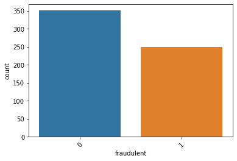

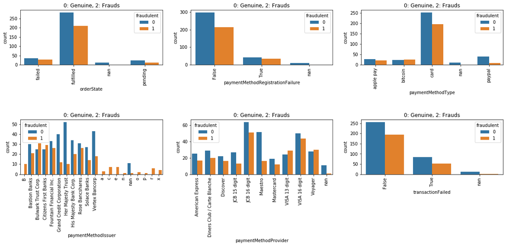

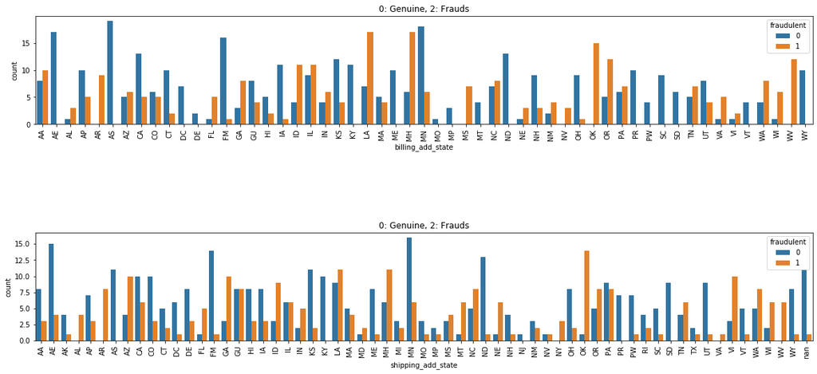

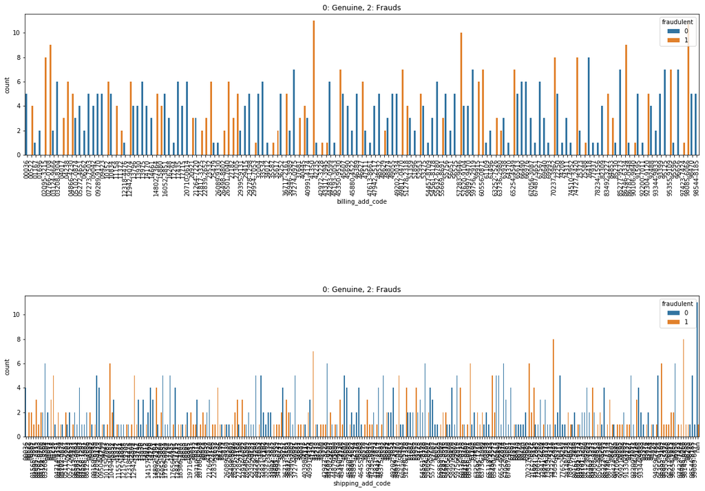

```python
da.get_column_ratios()

print("~~~~~~~~~~~~~~~~~~~~~~~~~ Now let's evaluate each column separately ~~~~~~~~~~~~~~~~~~~~~~~~~~~~~~~~")


smallplots = [ 'orderState', 'paymentMethodRegistrationFailure', 'paymentMethodType', 'paymentMethodIssuer', 'paymentMethodProvider',
              'transactionFailed']
da.countplots_small(smallplots)

bigplots = ['billing_add_state', 'shipping_add_state']
da.countplots_big(bigplots)

biggerplots = ['billing_add_code', 'shipping_add_code']
da.countplots_bigger(biggerplots)
```

Since the *data ratio is 40/60*, it doesn't impose class imbalance.  
Some interesting plots came up when I started looking at the proportions of frads vs genuines for various columns, e.g. plot for paymentMethodIssuer tells that if the *paymentMethodIssuer name is a single alphabet, then the customer is marked as Fraud*. To confirm it, I use another method from the class DataAnalisis

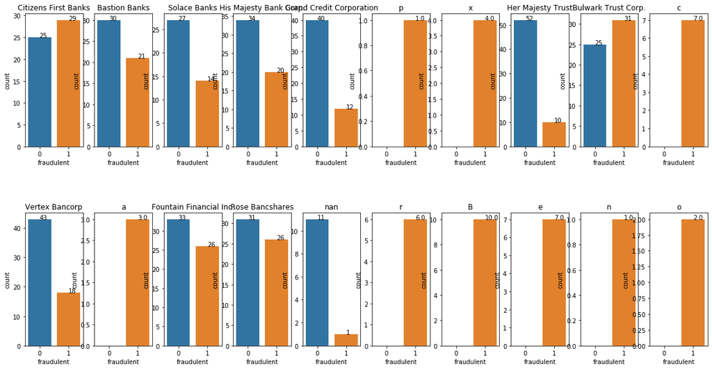

```python
da.draw_pmi()
```

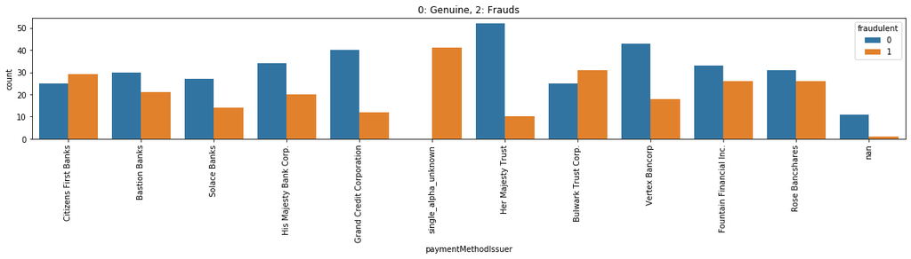

```python
da.binning(col_str='paymentMethodIssuer')

bigplots = ['paymentMethodIssuer']
da.countplots_big(bigplots)
```

Again, looking in the above graph for billing_add_state and shipping_add_state, it can be concluded that, some states are evidently fraudulents, such as *Oklahoma, West Virginia!*  
To have a clearer look, I plotted word clouds for both the variables

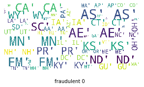

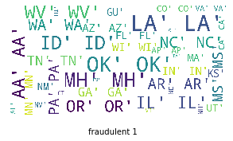

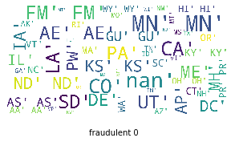

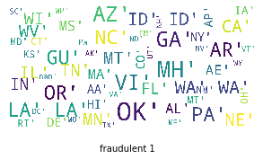

```
(None, None)
```

```python
da.draw_word_cloud('billing_add_state'), da.draw_word_cloud('shipping_add_state'),
```

```python
da.model['shipping_add_code'].nunique(), da.model['billing_add_code'].nunique()
```

```
(275, 151)
```

I also looked at address codes. Some of them seem to have higher tendency for frauds. However, to make a recommendation here for address codes, I would need more understanding on how the address codes work in US or if the above codes' data not a dummy data, then how on map these address codes are spread.  
Since out of 600 rows, we have 68 unique in orderAmount. I also checked, roughly, if orderAmount shows any trend in frauds. Yes, it does! Below, you'll see how with *increase in orderAmount the fraudulent column marks a customer => True indicating fraud*

```python
print(da.model.orderAmount.nunique())

da.get_unique_col_value_based_on_another_col(col_str='orderAmount')
```

```
68
```

```
orderAmount
10.0     {False, True}
11.0     {True, False}
12.0     {True, False}
13.0     {False, True}
14.0     {False, True}
15.0     {False, True}
16.0     {False, True}
17.0     {False, True}
18.0     {False, True}
19.0     {False, True}
20.0     {False, True}
21.0     {False, True}
22.0     {False, True}
23.0     {True, False}
24.0     {False, True}
25.0     {False, True}
26.0     {False, True}
27.0     {False, True}
28.0     {False, True}
29.0     {False, True}
30.0     {False, True}
31.0     {False, True}
32.0     {True, False}
33.0     {False, True}
34.0     {False, True}
35.0     {False, True}
353.0           {True}
36.0     {True, False}
37.0     {False, True}
38.0     {False, True}
39.0     {False, True}
40.0     {True, False}
41.0     {True, False}
42.0     {False, True}
43.0     {True, False}
44.0     {True, False}
45.0     {True, False}
46.0     {True, False}
47.0     {False, True}
```

[output cut: 15 more lines]

```
63.0            {True}
64.0            {True}
65.0            {True}
66.0            {True}
67.0            {True}
68.0            {True}
69.0            {True}
70.0            {True}
71.0            {True}
72.0            {True}
73.0            {True}
74.0            {True}
75.0            {True}
nan      {False, True}
Name: fraudulent, dtype: object
```

I then plot the distribution curves for the *numeric columns*.  
I see that numTransactions and numOrders seem to follow better *normal distribution*.  
orderAmount and numPaymentMethods are right skewed.  
First, I need to scalarize these columns and see their distributions

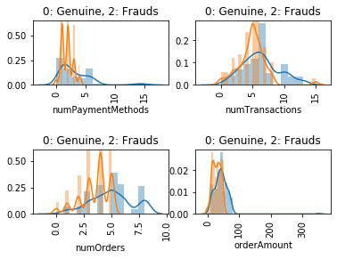

```python
da.draw_distplots()
```

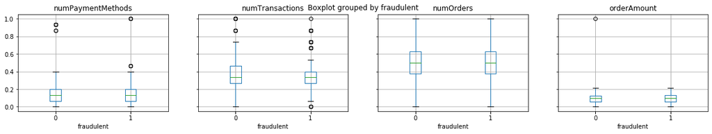

```python
da.scalarize_data()
da.set_plot_figsize()
da.draw_boxplots()
```

Since the dataset is very small, I avoid removing outliers. #todo: if the model doesn't turn out well

I also checked the distribution of numOrders vs numPaymentMethods vs numTransactions in a 3D plot. Below are 6 plots for all the permuted angles of a 3D plot. My conclusion from these graphs is: *More transactions and less num of payment methods can be an indicator of fraudulent*

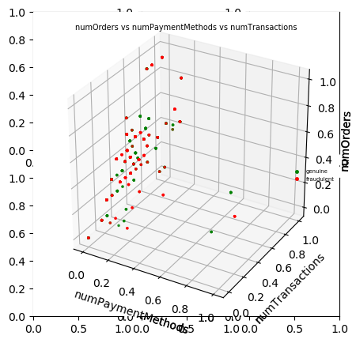

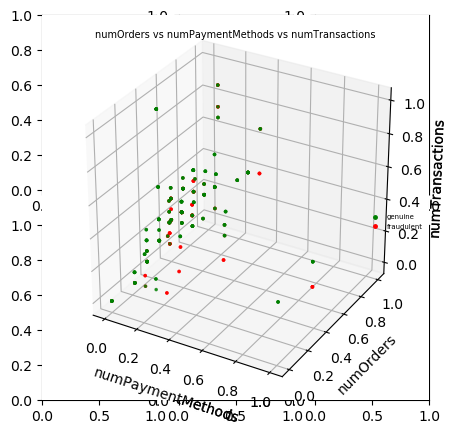

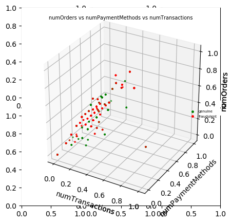

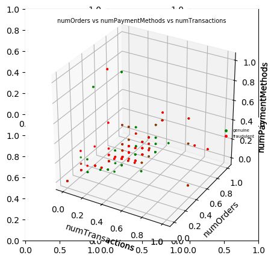

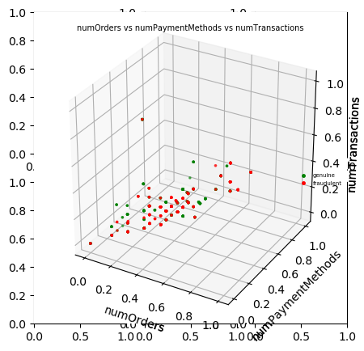

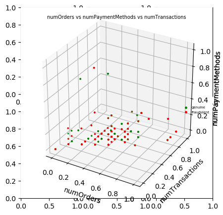

```python
da.draw_3D()
```

# 3) Explain what factors you think are significant and insignificant in contributing to fraud

This needs feature importance and feature selection on da.model dataset

For modeling the data and getting the correlation matrix, I need to convert the data in categorical columns to category codes format. The data types are changed using change_dtype method from DataAnalysis.  
Two plots are drawn:

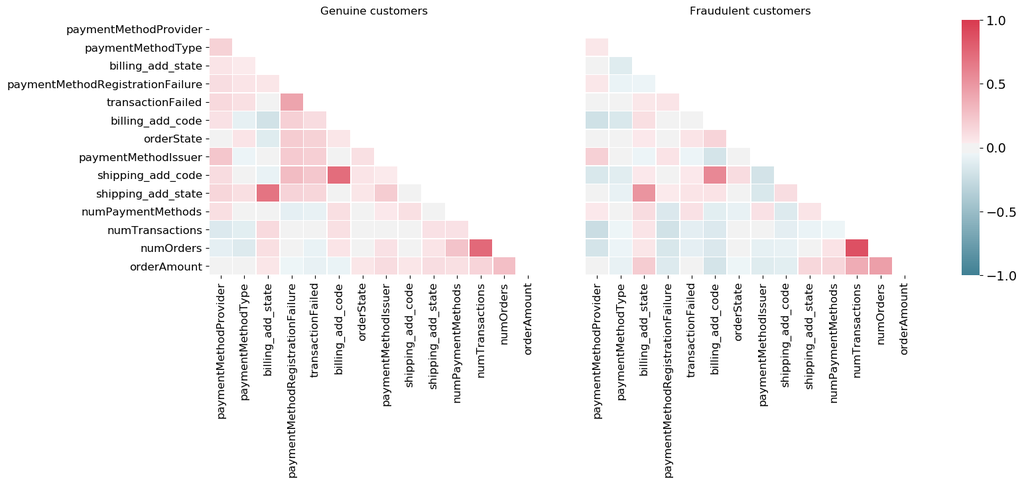

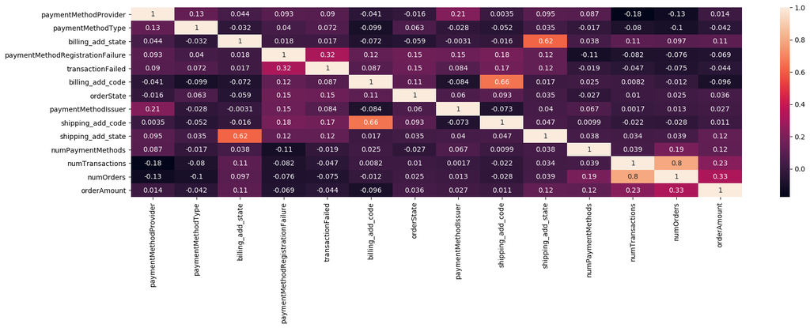

```python
da.change_dtype(cat_codes=True)
da.draw_corr_matrix()
```

For feature selection, first I use *RFE (Recursive Feature Elimination)* which selects features by recursively considering smaller and smaller sets of features; followed by using *XGBClassifier*. I also fit the models using these Classifiers and found that *XGBClassifier performs significantly better* than Logistic Regression, so *I recommend features suggested by XGBClassifier*

```python
X = da.model.drop(columns=('fraudulent'))
y = pd.DataFrame(da.model['fraudulent'])
print(X.shape, y.shape)
```

```
(600, 14) (600, 1)
```

```python
y['fraud_bool'] = y['fraudulent'].apply(lambda x: True if x==1 else False)# astype(bool)
y = y.drop(columns='fraudulent')
y = y.astype(int)
y.info()
```

```
<class 'pandas.core.frame.DataFrame'>
Int64Index: 600 entries, 0 to 634
Data columns (total 1 columns):
fraud_bool    600 non-null int32
dtypes: int32(1)
memory usage: 27.0 KB
```

Filtered out the NaNs and then replaced them with 0, and then cross check again if the code worked fine!

```python
X = X.fillna(0)
X[~X[list(X.columns)].notnull().all(1)]
```

|  | paymentMethodProvider | paymentMethodType | billing_add_state | paymentMethodRegistrationFailure | transactionFailed | billing_add_code | orderState | paymentMethodIssuer | shipping_add_code | shipping_add_state | numPaymentMethods | numTransactions | numOrders | orderAmount |
| --- | --- | --- | --- | --- | --- | --- | --- | --- | --- | --- | --- | --- | --- | --- |

```python
X_train, X_test, y_train, y_test = train_test_split(X, y, test_size=0.2, random_state=42)
```

*RFE Implementation*

```python
def feature_selection(X, y, num_features):
    logreg = LogisticRegression()
    rfe = RFE(logreg, num_features) # reduce the num of features to half
    rfe = rfe.fit(X, y.values.ravel())
    print(rfe.support_)
    print(rfe.ranking_)

    # get relevant columns
    def get_rel_col(rfe, rel_col=[]):
        i = 0
        for c in rfe.support_:
            if c:
                rel_col.append(list(X)[i])
            i += 1
        return rel_col

    rel_col = get_rel_col(rfe)
    df_temp = X[rel_col]

    logit_model = sm.Logit(y, df_temp)
    result=logit_model.fit(maxiter=30)
    print('for', num_features, 'num of features, model results are')
    print(result.summary2())
    return rel_col
```

In the next code, I ran RFE for various values of the num_features to be considered

```python
rel_col_dict = {}
for i in range(4, 15, 2):
    rel_col_dict[i] = feature_selection(X, y, num_features=i)
```

```
[False  True False False  True False False False False False False  True
 False  True]
[ 6  1  8  5  1 10  4  7 11  9  2  1  3  1]
Optimization terminated successfully.
         Current function value: 0.668204
         Iterations 4
for 4 num of features, model results are
                         Results: Logit
================================================================
Model:              Logit            Pseudo R-squared: 0.015
Dependent Variable: fraud_bool       AIC:              809.8442
Date:               2020-01-24 10:53 BIC:              827.4319
No. Observations:   600              Log-Likelihood:   -400.92
Df Model:           3                LL-Null:          -407.18
Df Residuals:       596              LLR p-value:      0.0058312
Converged:          1.0000           Scale:            1.0000
No. Iterations:     4.0000
----------------------------------------------------------------
                   Coef.  Std.Err.    z    P>|z|   [0.025 0.975]
----------------------------------------------------------------
paymentMethodType -0.1356   0.0696 -1.9491 0.0513 -0.2719 0.0008
transactionFailed -0.2602   0.1765 -1.4741 0.1405 -0.6061 0.0858
numTransactions   -0.1562   0.4221 -0.3699 0.7114 -0.9834 0.6711
orderAmount       -0.3504   1.3861 -0.2528 0.8004 -3.0671 2.3663
================================================================

[False  True False False  True False False False False False  True  True
  True  True]
[4 1 6 3 1 8 2 5 9 7 1 1 1 1]
Optimization terminated successfully.
         Current function value: 0.664959
         Iterations 5
for 6 num of features, model results are
                         Results: Logit
=================================================================
Model:               Logit            Pseudo R-squared: 0.020
Dependent Variable:  fraud_bool       AIC:              809.9508
Date:                2020-01-24 10:53 BIC:              836.3324
No. Observations:    600              Log-Likelihood:   -398.98
Df Model:            5                LL-Null:          -407.18
```

[output cut: 130 more lines]

```
paymentMethodProvider             0.0441   0.0311  1.4206 0.1554 -0.0168  0.1050
paymentMethodType                -0.3158   0.0927 -3.4054 0.0007 -0.4976 -0.1341
billing_add_state                 0.0191   0.0070  2.7165 0.0066  0.0053  0.0329
paymentMethodRegistrationFailure -0.1674   0.2231 -0.7504 0.4530 -0.6048  0.2699
transactionFailed                -0.3170   0.1940 -1.6343 0.1022 -0.6973  0.0632
billing_add_code                 -0.0020   0.0026 -0.7595 0.4476 -0.0070  0.0031
orderState                       -0.0975   0.1459 -0.6682 0.5040 -0.3833  0.1884
paymentMethodIssuer               0.0356   0.0264  1.3508 0.1768 -0.0161  0.0873
shipping_add_code                 0.0011   0.0014  0.7891 0.4300 -0.0017  0.0039
shipping_add_state               -0.0021   0.0062 -0.3435 0.7312 -0.0143  0.0101
numPaymentMethods                -0.5998   0.6505 -0.9219 0.3566 -1.8748  0.6753
numTransactions                  -1.9530   0.9676 -2.0185 0.0435 -3.8494 -0.0567
numOrders                         1.3331   0.7870  1.6939 0.0903 -0.2094  2.8756
orderAmount                      -2.8059   1.8629 -1.5062 0.1320 -6.4571  0.8453
================================================================================
```

```python
rel_col_dict[14]
```

```
['paymentMethodProvider',
 'paymentMethodType',
 'billing_add_state',
 'paymentMethodRegistrationFailure',
 'transactionFailed',
 'billing_add_code',
 'orderState',
 'paymentMethodIssuer',
 'shipping_add_code',
 'shipping_add_state',
 'numPaymentMethods',
 'numTransactions',
 'numOrders',
 'orderAmount']
```

Looking at the above results, the model with the max log-likelihood is also the one with max pseudo r-squared. It uses all the 14 features for analysis. rel_col_dict gives all the 14 columns for 14 num_features analysis.  
RFE suggests that all 14 variables be used for model fitting. However, looking at the p-values only 3 columns make sense. These include:

- paymentMethodType
- billing_add_state
- numTransactions

**XGBClassifier Implementation**

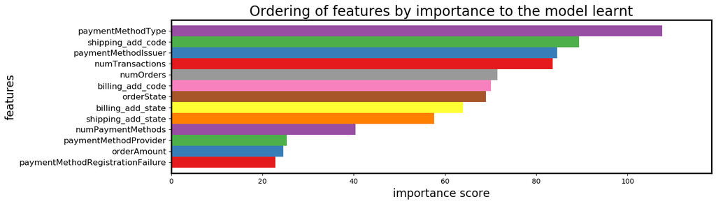

```python
Y = y.values
weights = (Y == 0).sum() / (1.0 * (Y == 1).sum())
clf = XGBClassifier(max_depth = 3, scale_pos_weight = weights, n_jobs = 4)
probabilities = clf.fit(X_train, y_train).predict_proba(X_test)

fig = plt.figure(figsize = (14, 4))
ax = fig.add_subplot(111)

colours = plt.cm.Set1(np.linspace(0, 1, 9))

ax = plot_importance(clf, height = 1, color = colours, grid = False, show_values = False, importance_type = 'cover', ax = ax)
for axis in ['top','bottom','left','right']:
    ax.spines[axis].set_linewidth(2)
    ax.set_xlabel('importance score', size = 16)
    ax.set_ylabel('features', size = 16)
    ax.set_yticklabels(ax.get_yticklabels(), size = 12)
    ax.set_title('Ordering of features by importance to the model learnt', size = 20)
```

The results of XGBClassifier implies:

- paymentMethodType: aligns with RFE results,
- numTransactions: aligns with RFE results,
- billing_add_state which was among the three most important features from RFE is not as important. However, going back to the correlation plot of billing_add_state, it showed relatively higher correlation

### Fit the model

Model Fitting using *Logistic Regression gives AUROC = 57%*

```python
logreg = LogisticRegression()
logreg.fit(X_train, y_train)
y_pred = logreg.predict(X_test)
auroc = str(round(roc_auc_score(y_test, y_pred)*100, 2))+'%'
#f1s = f1_score(y_test, y_pred, average='macro') # since no class imbalance
print('AUROC using Logitstic Regression is = {}'.format(auroc))
#print(f1s)
```

```
AUROC using Logitstic Regression is = 56.67%
```

Model Fitting using *XGBClassifier gives AUROC = 96%*

```python
auroc = str(round(roc_auc_score(y_test, probabilities[:, 1])*100, 2))+'%'
print('AUROC using XGBClassifier is = {}'.format(auroc))
```

```
AUROC using XGBClassifier is = 96.44%
```

Model Fitting using *Simple ANN gives AUROC = 52%*

```python
def ann(input_dim, dropout=0.2):
    model = Sequential([
    Dense(units=50, input_dim=input_dim, activation='relu'),
    Dropout(dropout),
    Dense(units=25, activation='relu'),
    Dropout(dropout),
    Dense(15, activation='relu'),
    Dense(1, activation='sigmoid')])
    return model
clf = ann(input_dim=X_train.shape[1], dropout=0.2)
clf.compile(optimizer='adam', loss='binary_crossentropy')
clf.fit(X_train, y_train, batch_size=50, epochs=5, verbose=1)
y_pred = clf.predict(X_test, verbose=1)
```

[output not shown]

```python
auroc = str(round(roc_auc_score(y_test, y_pred)*100, 2))+'%'
print('AUROC using ANN is = {}'.format(auroc))
```

```
AUROC using ANN is = 52.36%
```

**Since my model using XGB Classifier performs best, I suggest feaures given by XGBClassifier to be considered for distinguising between frauds and genuine customers**